# NYC Outbreak Analysis

Author

Varun V. Datta

```r
library(tidyverse)
library(tidybayes)
library(rstan)
library(gridExtra)
rstan_options (auto_write = TRUE)
options (mc.cores = parallel::detectCores ())
```

#Data Wrangling

This is for New York city and the data is sourced from https://github.com/nychealth/coronavirus-data which is a github repo linked on the NYC open data website.

```r
ny_df <- read_csv("/Users/varundatta/Desktop/STAD94/Bayesian_Repo/US-Covid_Inference/Data/NYC_Gov/cases-by-day.csv")
ny_df %>% mutate(date_of_interest = as.Date(date_of_interest, format = "%m/%d/%Y"))->ny_df
# Formatting the date into a proper date format
```

```r
ny_df %>% select(date_of_interest,CASE_COUNT)->covid_df
# selecting the columns we need
```

```r
covid_df<- covid_df %>% filter(date_of_interest <= as.Date("2020-06-25"))

# This is around the time the first wave had seemingly ended
covid_df
```

```
# A tibble: 118 × 2
   date_of_interest CASE_COUNT
   <date>                <dbl>
 1 2020-02-29                1
 2 2020-03-01                0
 3 2020-03-02                0
 4 2020-03-03                1
 5 2020-03-04                5
 6 2020-03-05                3
 7 2020-03-06                8
 8 2020-03-07                7
 9 2020-03-08               21
10 2020-03-09               57
# ℹ 108 more rows
```

## Plotting the cases

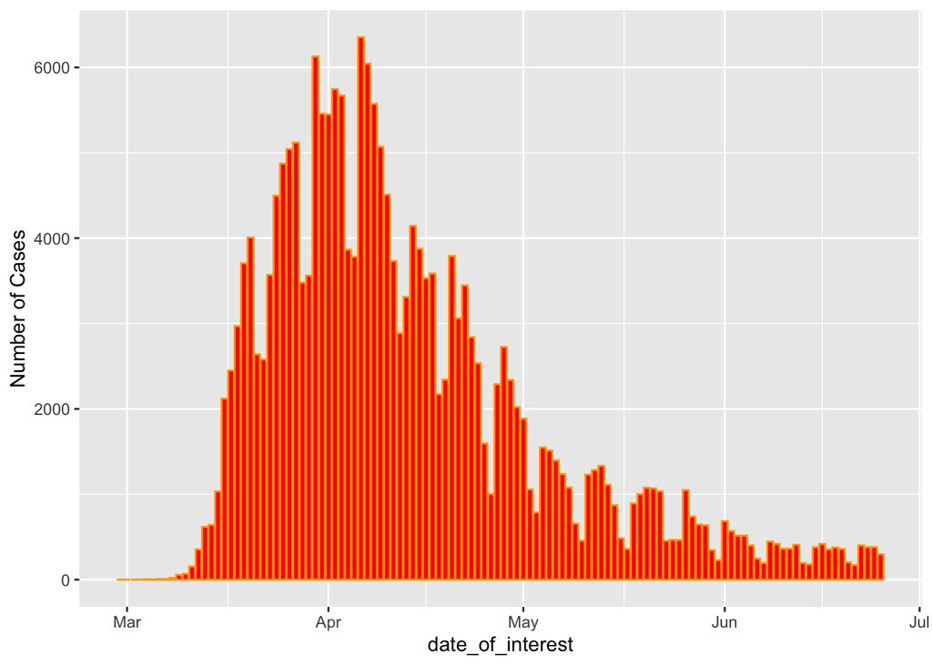

```r
covid_df %>% ggplot() + geom_bar(mapping =aes(x = date_of_interest,y=CASE_COUNT),fill = "red",color = "orange", stat = "identity") + labs(y = "Number of Cases")
```

## Initialziing

```r
### Initial parameter values

N <- N <- 8.773e6  # Population of New York

i0 <- 1 # Assuming one infected person started it all
s0 <- N - i0
r0 <- 0
y0 = c(S = s0, I = i0, R = r0)
```

## Extracting the data for Stan Model

```r
# Cases
cases <- covid_df$CASE_COUNT

# times
n_days <- length(cases)
t <- seq(1, n_days, by = 1)
t0 = 0
t <- t

data_sir <- list(n_days = n_days, y0 = y0, t0 = t0, ts = t, N = N, cases = cases)
```

## Desigining the model

We will be utilizing a SIR model of incidences with informative priors on our SIR parameters.

What are incidences?

In the SIR model, “incidence” is defined as the number of new cases of a disease that occur within a specific period, calculated by subtracting the total cases on day $n-1$ from the cases on day $n$

$$I_n = C_n - C_{n-1}$$

This metric is crucial for analyzing the disease’s transmission dynamics, as it quantifies the daily increase in cases, thereby offering insights into how rapidly the infection is spreading through the population.

```stan
for (i in 1:n_days-1)
  incidence[i] = y[i, 1] - y[i + 1, 1]; //S(t) - S(t + 1)
```

and the same negative-binomial likelihood from the model we used in the 1978 influneza inference (to account for overdispersion, whereas e.g a Poisson distribution would constrain the variance to be equal to the mean) and we fit these incidence parameters to the data:

```stan
cases[1:(n_days-1)] ~ neg_binomial_2(incidence, phi);
```

Let’s modify that model to add informative priors:

We know from the literature that the incubation time (average time between infection and symptoms) and generation time (average time between the symptom onsets of the infectious and the infected) are around 5 days[^1]. Therefore the time between infection and infectiousness can’t be so low.

Until now in our analysis, we have only used weakly-informative priors.But here we have accessible domain knowledge: we can refine our prior on $a$. In this case, it is easier to specify our domain knowledge on the inverse of $a$. We choose the informative prior $inv(a) \sim \mathcal{N}(6, 1)$, which means there is a priori a greater than 99% chance that our incubation time is between 3 and 9.

## Footnotes

[^1]: *Qifang Bi, Yongsheng Wu, Shujiang Mei, Chenfei Ye, Xuan Zou, Zhen Zhang, Xiaojian Liu, Lan Wei, Shaun A Truelove, Tong Zhang, et al. Epidemiology and transmission of COVID-19 in shenzhen china: Analysis of 391 cases and 1,286 of their close contacts. MedRxiv, 2020.* for the incubation time. *Tapiwa Ganyani, Cecile Kremer, Dongxuan Chen, Andrea Torneri, Christel Faes, Jacco Wallinga, and Niel Hens. Estimating the generation interval for COVID-19 based on symptom onset data. medRxiv, 2020.* for the generation time